# Module 2: Chi-Square testing and ANOVA

Sanchi Gupta, ALY6015 Intermediate Analytics

# Introduction:

In this module, we delve into the application of Chi-Square testing and ANOVA (Analysis of Variance), two pivotal statistical tools, to assess various hypotheses in different real-world scenarios. Chi-Square tests are employed to compare observed frequencies with expected frequencies and are instrumental in determining whether there are significant differences between categorical variables. ANOVA, on the other hand, is used to compare the means of three or more groups to ascertain if at least one group mean is statistically different from the others. Through the tasks presented in this module, we aim to provide practical insights into how these statistical methods can be applied to data samples from the healthcare sector, transportation industry, entertainment, and military service to draw meaningful conclusions.

# Task 1 (Section 11-1 6. Blood Types)

A medical researcher wishes to see if hospital patients in a large hospital have the same blood type distribution as those in the general population. The distribution for the general population is as follows:

- type A = 20%
- type B = 28%
- type O = 36%
- type AB = 16%

He selects a random sample of 50 patients and finds the following:

- 12 have type A blood
- 8 have type B
- 24 have type O
- 6 have type AB blood

At α = 0.10, can it be concluded that the distribution is the same as that of the general population?

# Solution

## $\chi^2$ Test

Forming of vectors of $expected$ probabilities and $observed$ frequencies, then we run the test afterwards.

```r
# Observed frequencies in the hospital sample
observed_1 <- c(12, 8, 24, 6)

# Expected frequencies based on the general population distribution
expected_1 <- c(0.20 * 50, 0.28 * 50, 0.36 * 50, 0.16 * 50)

# alpha
alpha_0.10 <- 0.10
```

### Step 1. Stating the hypotheses and identifying the claim

The hypothesis for the above will be as follow:

**Null Hypothesis** = The distribution of blood types in hospital patients is the same as that of the general population.

**Alternative Hypothesis** = The distribution of blood types in hospital patients is different from that of the general population.

### Step 2. Finding the critical value

When using the p-value for analysis, no critical value is needed. Because of this, we will use the provided p-value and omit this step.

### Step 3. Computing the test results

```r
# Chi-square test
chi_square_1 <- chisq.test(observed_1, p = expected_1 / sum(expected_1))

# Print the test results
print(chi_square_1)
```

```
##
##  Chi-squared test for given probabilities
##
## data:  observed_1
## X-squared = 5.4714, df = 3, p-value = 0.1404
```

### Step 4. Analyzing the results

**Interpretation:**

- If the p-value is less than the significance level (α = 0.10), then we would reject the null hypothesis. In this case, the p-value is 0.1404, which is greater than alpha = 0.10.

### Step 5. Summary

Therefore, based on the p-value, we would fail to reject the null hypothesis. There is not enough evidence to conclude that the distribution of blood types in hospital patients is different from that of the general population at a significance level of 0.10.

**The evidence leads us to not reject the null hypothesis.**

# Task 2 (Section 11-1. 8. On-Time Performance by Airlines)

According to the Bureau of Transportation Statistics, on-time performance by the airlines is described as follows:

| Action | **% of Time** |
| --- | --- |
| On-time | 70.8 |
| National Aviation System delay | 8.2 |
| Aircraft arriving late | 9.0 |
| Other (because of weather and other conditions) | 12.0 |

Records of 200 randomly selected flights for a major airline company showed that

- 125 planes were on time
- 40 were delayed because of weather
- 10 because of a National Aviation System delay
- 25 because of arriving late

At α = 0.05, do these results differ from the government’s statistics?

*Source:* www.transtats.bts.gov

# Solution

## $\chi^2$ Test

Forming of vectors of $expected$ probabilities and $observed$ frequencies, then we run the test afterwards.

```r
# Observed frequencies
observed_2 <- c(125, 10, 40, 200 - (125 + 10 + 40))

# Expected frequencies based on the given percentages
expected_2 <- c(0.708 * 200, 0.082 * 200, 0.090 * 200, 0.120 * 200)
```

### Step 1. Stating the hypotheses and identify the claim

The hypothesis for the above will be as follow:

**Null Hypothesis** = The distribution of on-time performance categories for the airline is consistent with the expected distribution provided by the Bureau of Transportation Statistics.

**Alternative Hypothesis** = There is a significant difference in the distribution of on-time performance categories for the airline compared to the expected distribution provided by the Bureau of Transportation Statistics.

### Step 2. Finding the critical value

When using the p-value for analysis, no critical value is needed. Because of this, we will use the provided p-value and omit this step.

### Step 3. Computing the test results

```r
# to set the results to numerical digits
options(scipen = 100, digits = 10)

# Chi-square test
chi_square_2 <- chisq.test(observed_2, p = expected_2 / sum(expected_2))

# Print the test results
print(chi_square_2)
```

```
##
##  Chi-squared test for given probabilities
##
## data:  observed_2
## X-squared = 31.374162, df = 3, p-value = 0.0000007090023
```

```r
options(scipen = 100, digits = 10)
```

### Step 4. Analyzing the results

**Interpretation:**

- If the p-value is less than the significance level (α = 0.05), we would reject the null hypothesis. In this case, the p-value is 0.0000007090023, which is far less than alpha = 0.05.

### Step 5. Summary

Therefore, based on the extremely small p-value, we would reject the null hypothesis. There is strong evidence to conclude that there is a significant difference in the distribution of on-time performance categories for the airline compared to the expected distribution provided by the Bureau of Transportation Statistics at a significance level of 0.05.

**The evidence leads us to reject the null hypothesis.**

# Task 3 (Section 11-2.8. Ethnicity and Movie Admissions)

Are movie admissions related to ethnicity? A 2014 study indicated the following numbers of admissions (in thousands) for two different years. At the 0.05 significance level, can it be concluded that movie attendance by year depended on ethnicity?

|  | **Caucasian** | **Hispanic** | **African American** | **Other** |
| --- | --- | --- | --- | --- |
| 2013 | 724 | 335 | 174 | 107 |
| 2014 | 370 | 292 | 152 | 140 |

*Source: MPAA Study*.

# Solution

## $\chi^2$ Test

```r
# Create vectors for the observed frequencies
observed_2013 <- c(724, 335, 174, 107)
observed_2014 <- c(370, 292, 152, 140)

# Combine the vectors into a matrix
movie_matrix_3 <- rbind(observed_2013, observed_2014)
```

### Step 1. Stating the hypotheses and identify the claim

The hypothesis for the above will be as follow:

**Null Hypothesis** = There is no association between movie attendance and ethnicity. In other words, movie attendance is independent of ethnicity.

**Alternative Hypothesis** = There is a significant association between movie attendance and ethnicity. Movie attendance is not independent of ethnicity.

### Step 2. Finding the critical value

When using the p-value for analysis, no critical value is needed. Because of this, we will use the provided p-value and omit this step.

### Step 3. Computing the test results

```r
# Perform chi-square test for independence
chi_square_3 <- chisq.test(movie_matrix_3)

# Print the test results
print(chi_square_3)
```

```
##
##  Pearson's Chi-squared test
##
## data:  movie_matrix_3
## X-squared = 60.143525, df = 3, p-value = 0.0000000000005477507
```

### Step 4. Analyzing the results

**Interpretation:**

- If the p-value is less than the significance level (α = 0.05), then we would reject the null hypothesis. Here, the p-value is 0.0000000000005477507, which is again less than alpha = 0.05.

### Step 5. Summary

We created a matrix since the chi-square test for independence was necessary. The contingency table structure helps in data organization and analysis because there are two variables in these situations.

Therefore, based on the extremely small p-value, we would reject the null hypothesis. There is strong evidence to conclude that movie attendance depends on ethnicity at a significance level of 0.05.

**The evidence leads us to reject the null hypothesis.**

# Task 4 (Section11-2.10 Women in the Military)

This table lists the numbers of officers and enlisted personnel for women in the military. At *α* = 0.05, is there sufficient evidence to conclude that a relationship exists between rank and branch of the Armed Forces?

[figure not shown]

*Source:* *New York Times Almanac*.

# Solution

## $\chi^2$ Test

```r
# Observed frequencies
army <- c(10791, 62491)
navy <- c(7816, 42750)
marine_corps <- c(932, 9525)
air_force <- c(11819, 54344)

# Combine the vectors into a matrix
military_matrix_4 <- rbind(army, navy, marine_corps, air_force)
```

### Step 1. Stating the hypotheses and identify the claim

The hypothesis for the above will be as follow:

**Null Hypothesis** = There is no relationship between the rank (officers or enlisted) and the branch of the Armed Forces for women. In other words, the distribution of officers and enlisted personnel is independent of the branch.

**Alternative Hypothesis** = There is a relationship between the rank (officers or enlisted) and the branch of the Armed Forces for women. The distribution of officers and enlisted personnel is not independent of the branch.

### Step 2. Finding the critical value

When using the p-value for analysis, no critical value is needed. Because of this, we will use the provided p-value and omit this step.

### Step 3. Computing the test results

```r
# Perform chi-square test for independence
chi_square_4 <- chisq.test(military_matrix_4)

# Print the test results
print(chi_square_4)
```

```
##
##  Pearson's Chi-squared test
##
## data:  military_matrix_4
## X-squared = 654.27189, df = 3, p-value < 0.00000000000000022204
```

### Step 4. Analyzing the results

**Interpretation:**

- The p-value associated with the chi-square test statistic is less than alpha=0.05, which is extremely small. Since this p-value is significantly less than the common alpha level of 0.05, it suggests that the observed data are highly unlikely to have occurred by random chance if the null hypothesis were true.

### Step 5. Summary

Therefore, based on the extremely small p-value, we would reject the null hypothesis. There is strong evidence to conclude that there is a significant relationship between the rank (officers or enlisted) and the branch of the Armed Forces for women. This suggests that the proportions of officers and enlisted personnel vary across different branches, indicating dependence between rank and branch in the military for women.

**The evidence leads us to reject the null hypothesis.**

# Task 5 (Section 12-1.8 Sodium Contents of Foods)

Perform a complete one-way ANOVA. If the null hypothesis is rejected, use either the Scheffé or Tukeytest to see if there is a significant difference in the pairs of means. Assume all assumptions are met.

The amount of sodium (in milligrams) in one serving for a random sample of three different kinds of foodsis listed. At the 0.05 significance level, is there sufficient evidence to conclude that a difference in mean sodium amounts exists among condiments, cereals, and desserts?

Source: The Doctor’s Pocket Calorie, Fat, and Carbohydrate Counter

| Condiments | Cereals | Desserts |
| --- | --- | --- |
| 270 | 260 | 100 |
| 130 | 220 | 180 |
| 230 | 290 | 250 |
| 180 | 290 | 250 |
| 80 | 200 | 300 |
| 70 | 320 | 360 |
| 200 | 140 | 300 |
|  |  | 160 |

# Solution

## ANOVA Test

```r
# Sodium amounts for three different kinds of foods
condiments <- c(270,130,230,180,80,70,200)
cereals    <- c(260,220,290,290,200,320,140)
desserts   <- c(100,180,250,250,300,360,300,160)

sample_5 <- matrix(c(rep("Condiments", 7), rep("Cereals", 7), rep("Desserts", 8), condiments ,
                  cereals, desserts),ncol=2)

df_5 <- data.frame(sample_5)

names(df_5) <- c('food_type', 'sodium_milligrams')
```

### Step 1. Stating the hypotheses and identify the claim

The hypothesis for the above will be as follow:

**Null Hypothesis** = The population means for sodium are equal across all three categories.

**Alternative Hypothesis** = There is a significant difference in the mean sodium amounts among condiments, cereals, and desserts. At least one population mean is different from the others.

### Step 2. Finding the critical value

When using the p-value for analysis, no critical value is needed. Because of this, we will use the provided p-value and omit this step.

### Step 3. Computing the test results

```r
# Perform one-way ANOVA
anova_result_5 <- aov(as.numeric(sodium_milligrams)~food_type, data=df_5)

# Print the ANOVA summary
summary(anova_result_5)
```

```
##             Df    Sum Sq   Mean Sq F value  Pr(>F)
## food_type    2  27543.51 13771.753 2.39854 0.11781
## Residuals   19 109092.86  5741.729
```

### Step 4. Analyzing the results

**Interpretation:**

- The p-value associated with the F-statistic tests the null hypothesis that there is no difference in means among the groups. If this p-value is less than the significance level (commonly 0.05), we would reject the null hypothesis. In this case, the p-value for “food_type” is 0.11781, which is greater than 0.05.

### Step 5. Summary

Therefore, at a 0.05 significance level, there is not sufficient evidence to conclude that a difference in mean sodium amounts exists among condiments, cereals, and desserts.

**The evidence leads us to not reject the null hypothesis.**

# Task 6 (Section 12-2.10 Sales for Leading Companies)

Perform a complete one-way ANOVA. If the null hypothesis is rejected, use either the Scheffé or Tukeytest to see if there is a significant difference in the pairs of means. Assume all assumptions are met.

The sales in millions of dollars for a year of a sample of leading companies are shown. At α = 0.01, isthere a significant difference in the means?

Source: Information Resources, Inc.

| **Cereal** | **Chocolate Candy** | **Coffee** |
| --- | --- | --- |
| 578 | 311 | 261 |
| 320 | 106 | 185 |
| 264 | 109 | 302 |
| 249 | 125 | 689 |
| 237 | 173 |  |

# Solution

## ANOVA Test

```r
# Sales data for different products
cereal  <- c(578, 320, 264, 249,237)
candy   <- c(311, 106, 109, 125,173)
coffee  <- c(261, 185, 302,689)


sample_6 <- matrix(c(rep("Cereal", 5), rep("Candy", 5), rep("Coffee", 4), cereal ,
                  candy, coffee),ncol=2)

df_6 <- data.frame(sample_6)

names(df_6) <- c('Sample_Type', 'Sales_in_million_dollars')
```

### Step 2. Finding the critical value

When using the p-value for analysis, no critical value is needed. Because of this, we will use the provided p-value and omit this step.

### Step 3. Computing the test results

```r
# Perform one-way ANOVA
anova_result_6 <- aov(as.numeric(Sales_in_million_dollars)~Sample_Type, data=df_6)

# Print the ANOVA summary
summary(anova_result_6)
```

```
##             Df   Sum Sq  Mean Sq F value  Pr(>F)
## Sample_Type  2 103769.6 51884.80 2.17178 0.16035
## Residuals   11 262794.8 23890.43
```

### Step 4. Analyzing the results

**Interpretation:**

- The p-value associated with the F-statistic tests the null hypothesis that there is no difference in means among the groups. If this p-value is less than the significance level = 0.01, we would reject the null hypothesis. In this case, the p-value for “Sample_Type” is 0.16035, which is greater than 0.01.

### Step 5. Summary

**The evidence leads us to not reject the null hypothesis.**

# Task 7 (Section 12-2.12 Per-Pupil Expenditures)

Perform a complete one-way ANOVA. If the null hypothesis is rejected, use either the Scheffé or Tukeytest to see if there is a significant difference in the pairs of means. Assume all assumptions are met.

The expenditures (in dollars) per pupil for states in three sections of the country are listed. Using α =0.05, can you conclude that there is a difference in means?

Source: New York Times Almanac

| Eastern Third | Middle Third | Western Third |
| --- | --- | --- |
| 4946 | 6149 | 5282 |
| 5953 | 7451 | 8605 |
| 6202 | 6000 | 6528 |
| 7243 | 6479 | 6911 |
| 6113 |  |  |

# Solution

## ANOVA Test

```r
# Expenditures data for different sections of the country
eastern        <- c(4946,5953,6202,7243,6113)
middle         <- c(6149,7451,6000,6479)
western        <- c(5282,8605,6528,6911)

sample_7 <- matrix(c(rep("eastern", 5), rep("middle", 4), rep("western", 4), eastern ,
                  middle, western),ncol=2)

# Convert the matrix to a data frame for easier analysis
df_7 <- data.frame(sample_7)

names(df_7) <- c('country_section', 'expenditure_dollars_per_pupil')
```

### Step 1. Stating the hypotheses and identify the claim

The hypothesis for the above will be as follow:

**Null Hypothesis** = The population means for expenditures are equal across all three sections.

**Alternative Hypothesis** = There is a significant difference in the mean expenditures per pupil among the Eastern Third, Middle Third, and Western Third sections of the country. At least one population mean is different from the others.

### Step 2. Finding the critical value

When using the p-value for analysis, no critical value is needed. Because of this, we will use the provided p-value and omit this step.

### Step 3. Computing the test results

```r
# Perform one-way ANOVA
anova_result_7 <- aov(as.numeric(expenditure_dollars_per_pupil)~country_section, data=df_7)

# Print the ANOVA summary
summary(anova_result_7)
```

```
##                 Df  Sum Sq  Mean Sq F value  Pr(>F)
## country_section  2 1244588 622294.0 0.64882 0.54333
## Residuals       10 9591145 959114.5
```

### Step 4. Analyzing the results

**Interpretation:**

- The p-value associated with the F-statistic tests the null hypothesis that there is no difference in means among the groups. If this p-value is greater than the significance level (commonly 0.05), we would fail to reject the null hypothesis. In this case, the p-value for “country_section” is 0.54333, which is greater than 0.05.

### Step 5. Summary

Therefore, at a 0.05 significance level, there is not sufficient evidence to conclude that a significant difference in mean expenditures per pupil exists among the Eastern Third, Middle Third, and Western Third sections of the country. The null hypothesis that all population means are equal is not rejected.

**The evidence leads us to not reject the null hypothesis.**

# Task 8 (Section 12-3.10 Increasing Plant Growth)

A gardening company is testing new ways to improve plant growth. Twelve plants are randomly selected and exposed to a combination of two factors:

• a “Grow-light” in two different strengths.

• a plant food supplement with different mineral supplements.

After several days, the plants are measured for growth, and the results (in inches) are put into the appropriate boxes.

|  | Grow Light 1 | Grow Light 2 |
| --- | --- | --- |
| Plant Food A | 9.2, 9.4, 8.9 | 8.5, 9.2, 8.9 |
| Plant Food B | 7.1, 7.2, 8.5 | 5.5, 5.8, 7.6 |

# Solution

## Two-way ANOVA Test

```r
# Growth data
grow_light_1_food_A <- c(9.2, 9.4, 8.9)
grow_light_2_food_A <- c(8.5, 9.2, 8.9)
grow_light_1_food_B <- c(7.1, 7.2, 8.5)
grow_light_2_food_B <- c(5.5, 5.8, 7.6)

# Create a matrix for plant growth data
sample_8 <- matrix(c(rep("grow_light_1", 6), rep("grow_light_2", 6), rep("food_A", 3), rep("food_B", 3), rep("food_A", 3), rep("food_B", 3) , grow_light_1_food_A , grow_light_1_food_B, grow_light_2_food_A , grow_light_2_food_B ),ncol=3)

# Convert the matrix to a data frame for easier analysis
df_8 <- data.frame(sample_8)

names(df_8) <- c('grow_light', 'food', 'improvements')
```

### Step 1. Stating the hypotheses and identify the claim

The hypothesis for the above will be as follow:

**Null Hypothesis** =

1. There is no interaction between the two factors (Grow-light and Plant food) in affecting plant growth.
2. There is no difference in mean growth with respect to light (Grow-light).
3. There is no difference in mean growth with respect to plant food.

**Alternative Hypothesis** =

1. There is an interaction between the two factors (Grow-light and Plant food) in affecting plant growth.
2. There is a difference in mean growth with respect to light (Grow-light).
3. There is a difference in mean growth with respect to plant food.

### Step 2. Finding the critical value

```r
alpha <- 0.05

# Degrees of freedom
dof1 <- 1  # for both main effects (grow light and plant food)
dof2 <- 8  # total observations minus the number of levels

# Critical value for grow light
critical_value_grow_light <- qf(1 - alpha, dof1, dof2)

# Critical value for plant food
critical_value_plant_food <- qf(1 - alpha, dof1, dof2)

critical_value_grow_light
```

```
## [1] 5.317655072
```

```r
critical_value_plant_food
```

```
## [1] 5.317655072
```

### Step 3. Computing the test results

```r
# Perform a two-way ANOVA
anova_result_8 <- aov(improvements ~ grow_light * food, data = df_8)
# (OpenAI, 2024)
# (F. E. (2020, July 30))

# Print the ANOVA summary
summary(anova_result_8)
```

```
##                 Df    Sum Sq   Mean Sq  F value    Pr(>F)
## grow_light       1  1.920000  1.920000  3.68051 0.0913314 .
## food             1 12.813333 12.813333 24.56230 0.0011124 **
## grow_light:food  1  0.750000  0.750000  1.43770 0.2648194
## Residuals        8  4.173333  0.521667
## ---
## Signif. codes:  0 '***' 0.001 '**' 0.01 '*' 0.05 '.' 0.1 ' ' 1
```

### Step 4. Analyzing the results

**Interpretation:**

- **grow_light**:
  - **F value**: 3.68051
  - Since 3.68051 is less than the critical value of 5.318, the effect of grow light strength on plant growth is not statistically significant at the 0.05 level.
- **food (Plant Food)**:
  - **F value**: 24.56230
  - Since 24.56230 is greater than the critical value of 5.318, the effect of plant food supplement on plant growth is statistically significant at the 0.05 level.
- **grow_light:food (Interaction between Grow Light and Food)**:
  - **F value**: 1.43770
  - Since 1.43770 is less than the critical value of 5.318, the interaction between grow light strength and plant food type does not significantly affect plant growth at the 0.05 level.

### Step 5. Summary

In summary, based on the critical F value (5.318), only the type of plant food supplement (food) has a significant impact on plant growth. Neither the grow light strength nor the interaction between grow light strength and plant food type shows a significant effect.

The type of plant food supplement significantly affects plant growth, while the grow light strength and the interaction between grow light strength and plant food type do not have a significant effect at the 0.05 level.

# Task 9

# Solution

### 9.1 Importing the dataset

```r
# Importing libraries
library(ggplot2)
library(dplyr)
library(corrplot)
library(tibble)

# Loading the data
baseball <- read.csv('baseball-3.csv')
```

### 9.2 Exploratory Data Analysis

#### a. Descriptive Statistics

```r
# Summary statistics
summary(baseball)
```

```
##      Team              League               Year                RS
##  Length:1232        Length:1232        Min.   :1962.000   Min.   : 463.000
##  Class :character   Class :character   1st Qu.:1976.750   1st Qu.: 652.000
##  Mode  :character   Mode  :character   Median :1989.000   Median : 711.000
##                                        Mean   :1988.958   Mean   : 715.082
##                                        3rd Qu.:2002.000   3rd Qu.: 775.000
##                                        Max.   :2012.000   Max.   :1009.000
##
##        RA                 W                  OBP                 SLG
##  Min.   : 472.000   Min.   : 40.00000   Min.   :0.2770000   Min.   :0.3010000
##  1st Qu.: 649.750   1st Qu.: 73.00000   1st Qu.:0.3170000   1st Qu.:0.3750000
##  Median : 709.000   Median : 81.00000   Median :0.3260000   Median :0.3960000
##  Mean   : 715.082   Mean   : 80.90422   Mean   :0.3263312   Mean   :0.3973417
##  3rd Qu.: 774.250   3rd Qu.: 89.00000   3rd Qu.:0.3370000   3rd Qu.:0.4210000
##  Max.   :1103.000   Max.   :116.00000   Max.   :0.3730000   Max.   :0.4910000
##
##        BA               Playoffs           RankSeason        RankPlayoffs
##  Min.   :0.2140000   Min.   :0.0000000   Min.   :1.000000   Min.   :1.000000
##  1st Qu.:0.2510000   1st Qu.:0.0000000   1st Qu.:2.000000   1st Qu.:2.000000
##  Median :0.2600000   Median :0.0000000   Median :3.000000   Median :3.000000
##  Mean   :0.2592727   Mean   :0.1980519   Mean   :3.122951   Mean   :2.717213
##  3rd Qu.:0.2680000   3rd Qu.:0.0000000   3rd Qu.:4.000000   3rd Qu.:4.000000
##  Max.   :0.2940000   Max.   :1.0000000   Max.   :8.000000   Max.   :5.000000
##                                          NA's   :988        NA's   :988
##        G                 OOBP                OSLG
##  Min.   :158.0000   Min.   :0.2940000   Min.   :0.3460000
##  1st Qu.:162.0000   1st Qu.:0.3210000   1st Qu.:0.4010000
##  Median :162.0000   Median :0.3310000   Median :0.4190000
##  Mean   :161.9188   Mean   :0.3322643   Mean   :0.4197429
##  3rd Qu.:162.0000   3rd Qu.:0.3430000   3rd Qu.:0.4380000
##  Max.   :165.0000   Max.   :0.3840000   Max.   :0.4990000
##                     NA's   :812         NA's   :812
```

This summarizes the data types for each column in the dataset. It also provides us the data type for each variable along with mean for the numerical columns.

#### b. Graphical Representation

**Plot 1: Histogram of wins**

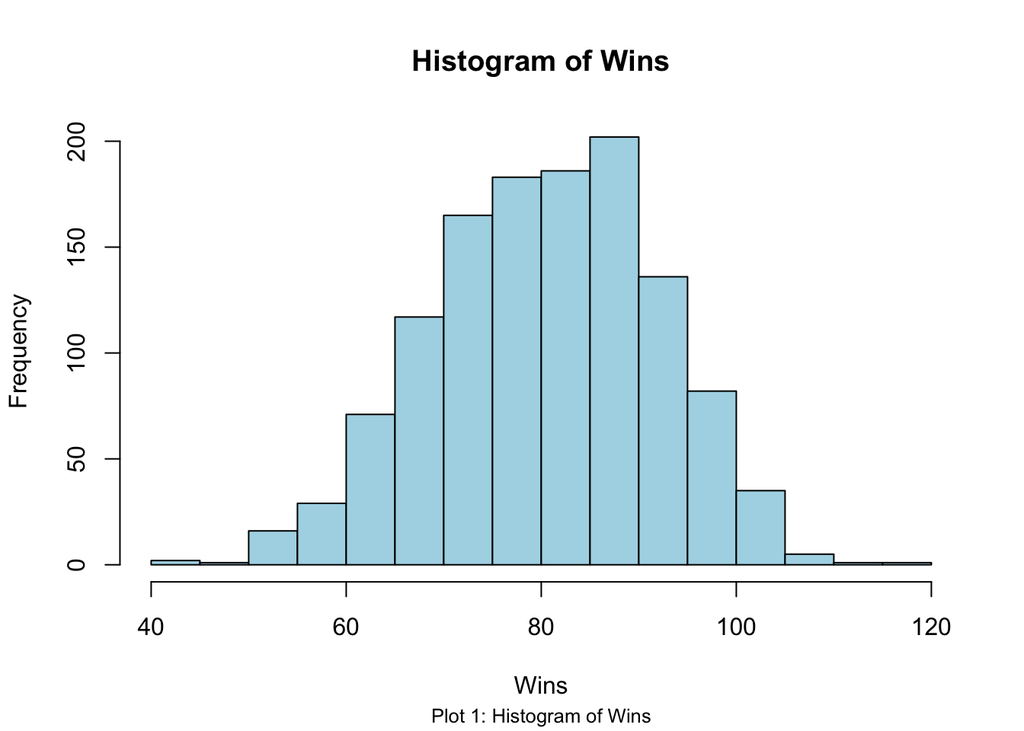

```r
# Plotting histogram for the Wins
hist(baseball$W,
     main = "Histogram of Wins",
     xlab = "Wins",
     col = "lightblue",
     border = "black")

# Adding title below the plot
mtext("Plot 1: Histogram of Wins", side = 1, line = 4, cex = 0.8)
```

**Interpretation of Plot 1: Histogram of Wins**

This histogram gives a visual representation of the distribution of wins. The horizontal axis represents each bin as a range of wins. The vertical axis shows the frequency, which is the number of occurrences within each bin. The histogram have the highest frequency in the central bins and lower frequencies in the bins on either end, suggesting a roughly symmetric distribution around the center. This indicates a normal distribution. Most teams or individuals have a number of wins that cluster around the middle range, with fewer teams having very low or very high numbers of wins.

**Plot 2: Correlation Matrix**

```r
# Correlation matrix for numeric variables
numeric_extract <- baseball %>% select(Year, RS, RA, W, OBP, SLG, BA, RankSeason, RankPlayoffs, G, OOBP, OSLG)

# Calculating correlation matrix
correlation_table <- cor(numeric_extract, use = "complete.obs")
```

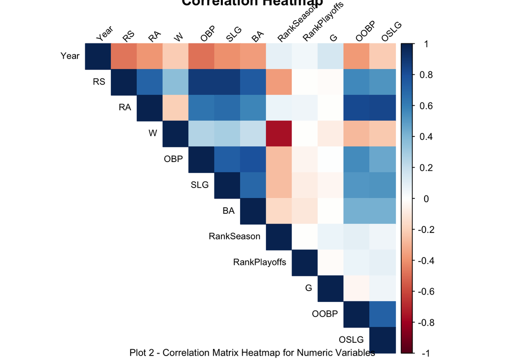

```r
# Plotting correlation matrix
corrplot(correlation_table,
         method = "color",
         type = "upper",
         tl.col = "black",
         tl.srt = 45,
         tl.cex = 0.75,
         addrect = 4,
         title = "Correlation Heatmap")

# Adding title below the plot
mtext("Plot 2 - Correlation Matrix Heatmap for Numeric Variables", side = 1, line = 4, cex = 0.8)
```

**Interpretation of Plot 2: Correlation Matrix Heatmap for Numeric Variables**

**Variable Names**: Along the axes, “Year,” “RS,” “RA,” “W,” “OBP,” “SLG,” “BA,” “RankSeason,” “RankPlayoffs,” “G,” “OOBP,” and “OSLG” are likely abbreviations for statistical categories.

- RS could be “Runs Scored”
- RA could be “Runs Allowed”
- W could be “Wins”
- OBP could be “On-base Percentage”
- SLG could be “Slugging Percentage”
- BA could be “Batting Average”
- G could be “Games Played”
- OOBP could be “Opponents’ On-base Percentage”
- OSLG could be “Opponents’ Slugging Percentage”

**Color Scale**: There is a color scale on the side, with colors representing the strength and direction of the correlation. In the above heatmap darker blue indicates a stronger positive correlation, and darker red indicates a stronger negative correlation, with lighter colors or white indicating a weaker correlation.

**Plot 3: Scatter plot with a linear regression line**

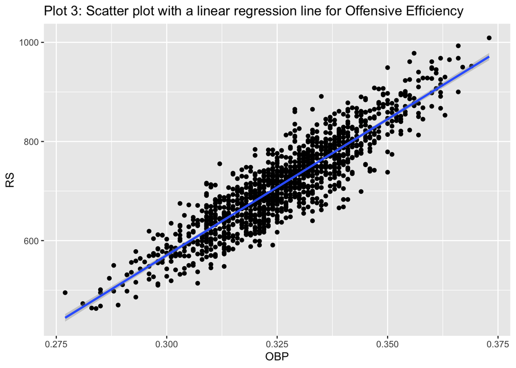

```r
# plotting scatter plot with a linear regression line
 ggplot(baseball, aes(x = OBP, y = RS)) +
  geom_point() +
  geom_smooth(method = 'lm') +
  labs(title = "Plot 3: Scatter plot with a linear regression line for Offensive Efficiency")
```

**Interpretation of Plot 3: Scatter plot with a linear regression line for Offensive Efficiency**

The position of the dot corresponds to the OBP value for that observation on the horizontal axis and the RS value on the vertical axis. There appears to be a positive correlation between OBP and RS, as the dots show an upward trend from left to right. This suggests that higher on-base percentages tend to be associated with higher numbers of runs scored. The blue line represents a linear regression model that best fits the data. The positive slope of the line confirms the positive relationship between OBP and RS. This line can be used to predict RS from OBP.

In conclusion, the scatter plot suggests a statistically significant and positive relationship between a team’s or player’s OBP and the number of runs they score, which is a key aspect of offensive efficiency in baseball.

**Plot 4: Line plots for league averages of key statistics**

```
## No summary function supplied, defaulting to `mean_se()`
```

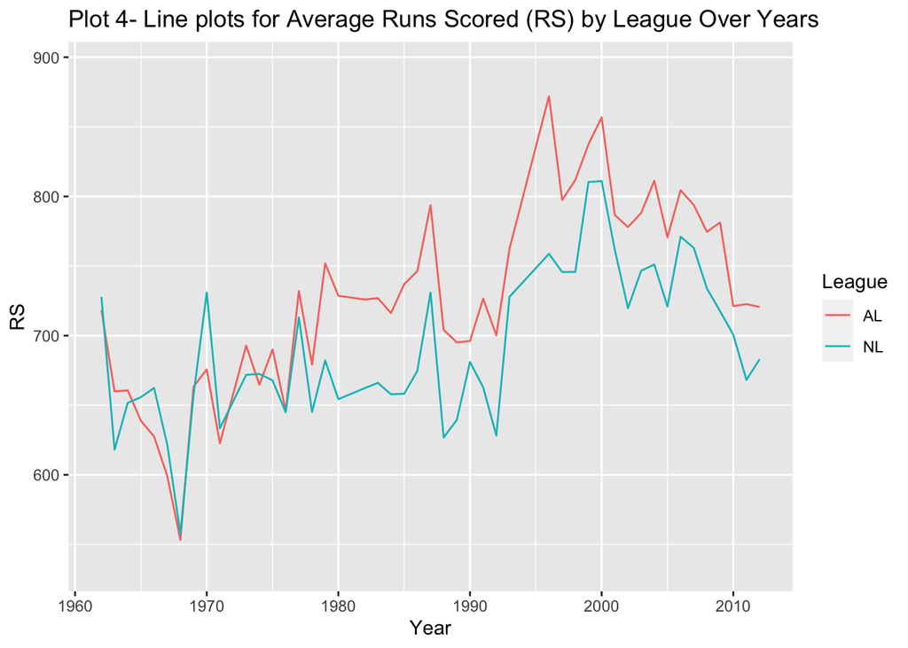

```r
# Plotting line plot
ggplot(baseball, aes(x = Year, y = RS, group = League, color = League)) +
  geom_line(stat = "summary", fun.y = "mean") +
  labs(title = "Plot 4- Line plots for Average Runs Scored (RS) by League Over Years")
```

**Interpretation of Plot 4: Line plots for Average Runs Scored (RS) by League Over Years**

The graph shows how the average runs scored have varied over the years in each league. There are two lines, one for each league (AL in red and NL in cyan). Each point on the line represents the average runs scored by the teams in that league for a given year. At various times, one line is above the other, indicating that in those years, one league had a higher average of runs scored than the other. Both leagues show a general upward trend in runs scored from the 1960s to the late 1990s/early 2000s, after which there is a visible decline. It’s also worth noting the difference in trends between the two leagues. For example, in the late 1990s and early 2000s, the AL shows a higher run-scoring average than the NL, which might be attributed to the use of the designated hitter (DH) rule, which is used in the AL but not in the NL.

### 9.3 Chi-Square Goodness-of-Fit test

Form the vectors of $expected$ probabilities and $observed$ frequencies, then run the test

```r
# Extract decade from year
baseball$Decade <- baseball$Year - (baseball$Year %% 10)

# Create a wins table by summing the wins by decade
wins <- baseball %>%
group_by(Decade) %>%
summarize(wins = sum(W)) %>%
as.tibble()
number_of_decades <- length(unique(baseball$Decade))

# Expected proportions for each decade
expected_wins <- rep(1/number_of_decades, number_of_decades)
```

### Step 1. Stating the hypotheses and identifying the claim

The hypothesis for the above will be as follow:

**Null Hypothesis** = There is no difference in the number of wins by decade.

**Alternative Hypothesis** = There is significant difference in the number of wins by decade.

### Step 2. Finding the critical value

```r
# Finding the critical value at alpha=0.05
critical_value_9.3 <- qchisq(p = 0.95, df = length(wins$wins) - 1)

print(critical_value_9.3)
```

```
## [1] 11.07049769
```

### Step 3. Computing the test results

```r
# Chi-square test
chi_square_9.3<- chisq.test(x = wins$wins, p = expected_wins)

# Print the result
print(chi_square_9.3)
```

```
##
##  Chi-squared test for given probabilities
##
## data:  wins$wins
## X-squared = 9989.5364, df = 5, p-value < 0.00000000000000022204
```

### Step 4. Analyzing the results

**Interpretation:**

- When comparing the Chi-squared test statistic to the critical value:
  - If the test statistic is greater than the critical value, wereject the null hypothesis.
  - If the test statistic is less than the critical value, we fail to reject the null hypothesis
- Since test statistic (9989.5364) is much greater than the critical value (11.07049769), we reject the null hypothesis. This means that the observed frequency distribution of “wins” is significantly different from the expected distribution, assuming that the expected frequencies were based on the given probabilities.

### Step 5. Does comparing the critical and test values provide the same result as comparing the p-value from R with the significance level?

Yes, comparing the test statistic to the critical value effectively provides the same result as comparing the p-value to the significance level.

The Chi-squared test statistic is 9989.5364, which is much greater than the critical value of 11.07049769. This would lead to reject the null hypothesis. The p-value is less than 0.00000000000000022204, which is certainly less than any conventional alpha level. This would also lead to reject the null hypothesis. Our overall conclusion in both situations is to reject the null hypothesis.

### 9.4 Download and import the dataset

```r
# Reading the dataset
crop_df <- read.csv("crop_data-3.csv")
```

### 9.5 Two-way ANOVA Test

### Step 1. Stating the hypotheses and identify the claim

The hypothesis for the above will be as follow:

1. **Main Effect of Density**:
   - Null Hypothesis: The mean response variable is the same across different levels of density.
   - Alternative Hypothesis: The mean response variable differs between at least two different levels of density.
2. **Main Effect of Fertilizer**:
   - Null Hypothesis: The mean response variable is the same across different levels of fertilizer.
   - Alternative Hypothesis: The mean response variable differs between at least two different levels of fertilizer.
3. **Interaction Effect of Density and Fertilizer**:
   - Null Hypothesis: There is no interaction effect between density and fertilizer on the mean response variable; any effect of one factor on the response variable is consistent at all levels of the other factor.
   - Alternative Hypothesis: There is an interaction effect between density and fertilizer on the mean response variable; the effect of one factor on the response variable depends on the level of the other factor.

### Step 3. Computing the test results

```r
# Perform Two-way ANOVA
anova_result_9.5 <- aov(yield ~ density * fertilizer, data = crop_df)

# Display the ANOVA table
summary(anova_result_9.5)
```

```
##                    Df    Sum Sq  Mean Sq  F value      Pr(>F)
## density             1  5.121681 5.121681 15.22973  0.00018111 ***
## fertilizer          1  5.743223 5.743223 17.07793 0.000079023 ***
## density:fertilizer  1  0.150187 0.150187  0.44659  0.50563029
## Residuals          92 30.939141 0.336295
## ---
## Signif. codes:  0 '***' 0.001 '**' 0.01 '*' 0.05 '.' 0.1 ' ' 1
```

### Step 4. Analyzing the results

1. **Main Effect of Density**:
   - **Pr(>F)**: 0.00018111, the p-value associated with the F statistic. Since it’s much lower than 0.05, there is a statistically significant effect of plant density on the response variable.
2. **Main Effect of Fertilizer**:
   - **Pr(>F)**: 0.000079023, which is also well below 0.05, indicating a statistically significant effect of the fertilizer on the response variable.
3. **Interaction Effect of Density and Fertilizer**:
   - **Pr(>F)**: 0.50563029, which is greater than 0.05, suggesting that there is no statistically significant interaction effect between plant density and fertilizer on the response variable.

### Step 5. Summary

- The null hypothesis for the main effect of density is rejected (there is a significant effect of density).
- The null hypothesis for the main effect of fertilizer is rejected (there is a significant effect of fertilizer).
- The null hypothesis for the interaction effect of density and fertilizer is not rejected (there is no significant interaction effect).

# Conclusion:

  Throughout the module, we observed the robustness of Chi-Square testing and ANOVA in a variety of contexts—from healthcare and aviation to entertainment and military demographics. In healthcare, we evaluated if the distribution of blood types in a hospital matched the general population. In aviation, we assessed an airline’s on-time performance against national statistics. For entertainment, we explored the relationship between ethnicity and movie admissions. In the military, we examined the association between rank and military branch for female personnel. Finally, we looked at sodium contents in food and sales among leading companies to understand differences in means across groups.

  In each task, the importance of matching the correct statistical test to the research question at hand was evident. The ability to interpret p-values and understand their relationship with alpha levels was crucial in drawing appropriate conclusions. These analyses, grounded in statistical theory, provide a foundation for evidence-based decision-making, reinforcing the value of quantitative reasoning in addressing complex questions.

# References:

- *OpenAI. (2021). ChatGPT (Version 3.5). OpenAI.https://chat.openai.com/*
- F. E. (2020, July 30). *Two Way ANOVA in R*. YouTube. https://www.youtube.com/watch?v=oEaS_yKJ8lM